# Lista 3

Gustavo S.W Finger

2026-04-04

## Carregando as bilbiotecas necessárias

Caso as biliotecas não estejam instaladas, faz-se necessário a instalação por meio do comando install.packages()

```r
library(tidyverse)
library(readr)
library(ggplot2)
```

## Carregando o arquivo com os dados para análise

Atenção:

Os dados estão disponíveis no seguinte endereço:

**[Baixar dados da ANAC](https://sistemas.anac.gov.br/dadosabertos/Voos%20e%20opera%C3%A7%C3%B5es%20a%C3%A9reas/Dados%20Estat%C3%ADsticos%20do%20Transporte%20A%C3%A9reo/Dados_Estatisticos.csv)**

Necessário realizar o download para a pasta do seu diretório ou realizar a importação por meio do link. url <- “https://sistemas.anac.gov.br/dadosabertos/Voos%20e%20opera%C3%A7%C3%B5es%20a%C3%A9reas/Dados%20Estat%C3%ADsticos%20do%20Transporte%20A%C3%A9reo/Dados_Estatisticos.csv”

```r
url<-"C:/Users/finge/OneDrive/2. Doutorado/1. Disciplina Métodos Computacionais Para estatística/Aula 2 - Módulos/Módulos/Modulo2/Dados_Estatisticos.csv"

dados<-read_csv2(url, col_names=TRUE, skip=1) #

print(paste0("Número de colunas nos dados: ",ncol(dados)))
```

```
## [1] "Número de colunas nos dados: 38"
```

```r
colnames(dados)
```

```
##  [1] "EMPRESA_SIGLA"                   "EMPRESA_NOME"
##  [3] "EMPRESA_NACIONALIDADE"           "ANO"
##  [5] "MES"                             "AEROPORTO_DE_ORIGEM_SIGLA"
##  [7] "AEROPORTO_DE_ORIGEM_NOME"        "AEROPORTO_DE_ORIGEM_UF"
##  [9] "AEROPORTO_DE_ORIGEM_REGIAO"      "AEROPORTO_DE_ORIGEM_PAIS"
## [11] "AEROPORTO_DE_ORIGEM_CONTINENTE"  "AEROPORTO_DE_DESTINO_SIGLA"
## [13] "AEROPORTO_DE_DESTINO_NOME"       "AEROPORTO_DE_DESTINO_UF"
## [15] "AEROPORTO_DE_DESTINO_REGIAO"     "AEROPORTO_DE_DESTINO_PAIS"
## [17] "AEROPORTO_DE_DESTINO_CONTINENTE" "NATUREZA"
## [19] "GRUPO_DE_VOO"                    "PASSAGEIROS_PAGOS"
## [21] "PASSAGEIROS_GRATIS"              "CARGA_PAGA_KG"
## [23] "CARGA_GRATIS_KG"                 "CORREIO_KG"
## [25] "ASK"                             "RPK"
## [27] "ATK"                             "RTK"
## [29] "COMBUSTIVEL_LITROS"              "DISTANCIA_VOADA_KM"
## [31] "DECOLAGENS"                      "CARGA_PAGA_KM"
## [33] "CARGA_GRATIS_KM"                 "CORREIO_KM"
## [35] "ASSENTOS"                        "PAYLOAD"
## [37] "HORAS_VOADAS"                    "BAGAGEM_KG"
```

## Lista 03

## Questão 1

*1-) Considere que é de interesse visualizar a série temporal (anual) do número de decolagens para as 10 empresas nacionais que mais decolaram no período disponível de dados. Faça duas visualizações uma para enfatizar a comparação entre as empresas e outra para enfatizar a visualização da série de cada empresa. Considere apenas os registros que tenham o número de decolagens.*

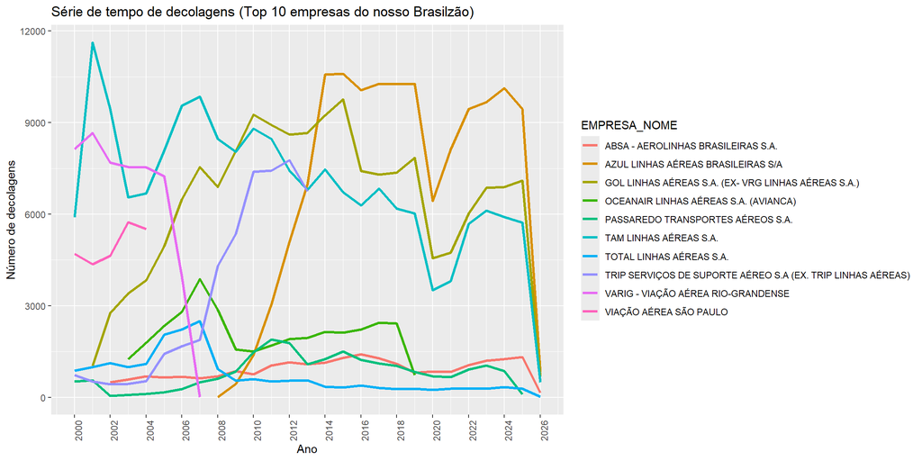

```r
questao_1_lista3  <- dados %>%
                    filter(EMPRESA_NACIONALIDADE == "BRASILEIRA") %>%
                    count(EMPRESA_NOME, name = "Decolagens") %>%
                    arrange(desc(Decolagens))%>%
                    mutate(percentual = Decolagens / sum(Decolagens) * 100) %>%
                    slice_head(n=10) %>%
                    pull(EMPRESA_NOME)

# Guardando os dados no tempo
questao_1_lista3_b <- dados %>%
                      filter(EMPRESA_NACIONALIDADE == "BRASILEIRA", EMPRESA_NOME %in% questao_1_lista3) %>%
                      count(ANO, EMPRESA_NOME, name = "Decolagens")

ggplot(questao_1_lista3_b, aes(x = ANO, y = Decolagens, color = EMPRESA_NOME)) +
        geom_line(linewidth = 1.2) +
        labs(
          title = "Série de tempo de decolagens (Top 10 empresas do nosso Brasilzão)",
          x = "Ano",
          y = "Número de decolagens"
            ) +
        scale_x_continuous(breaks = seq(min(questao_1_lista3_b$ANO), max(questao_1_lista3_b$ANO), by = 2))+
        guides(color = guide_legend(ncol = 1))+
        theme(
          legend.position = "right",
          axis.text.x = element_text(angle = 90, hjust = 1),
          strip.text = element_text(size = 10)
             )
```

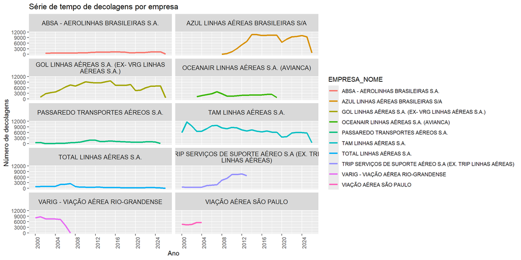

```r
ggplot(questao_1_lista3_b, aes(x = ANO, y = Decolagens, color = EMPRESA_NOME)) +
        geom_line(linewidth = 1.2) +
        facet_wrap(~EMPRESA_NOME,ncol = 2, labeller = label_wrap_gen(width = 45))+
        labs(
          title = "Série de tempo de decolagens por empresa",
          x = "Ano",
          y = "Número de decolagens"
            ) +
        scale_x_continuous(breaks = seq(min(questao_1_lista3_b$ANO), max(questao_1_lista3_b$ANO), by = 4))+
        guides(color = guide_legend(ncol = 1))+
        theme(
          legend.position = "right",
          axis.text.x = element_text(angle = 90, hjust = 1),
          strip.text = element_text(size = 10)
             )
```

## Questão 2

*2-) Faça uma visualização de dados comparar o número de passageiros pagantes entre empresas nacionais e estrangeiras ao longo dos anos.*

```r
questao_2_lista3 <- dados %>%
                    group_by(ANO, EMPRESA_NACIONALIDADE)  %>%
                    summarise(passageiro_pagantes = sum(PASSAGEIROS_PAGOS, na.rm=TRUE))
```

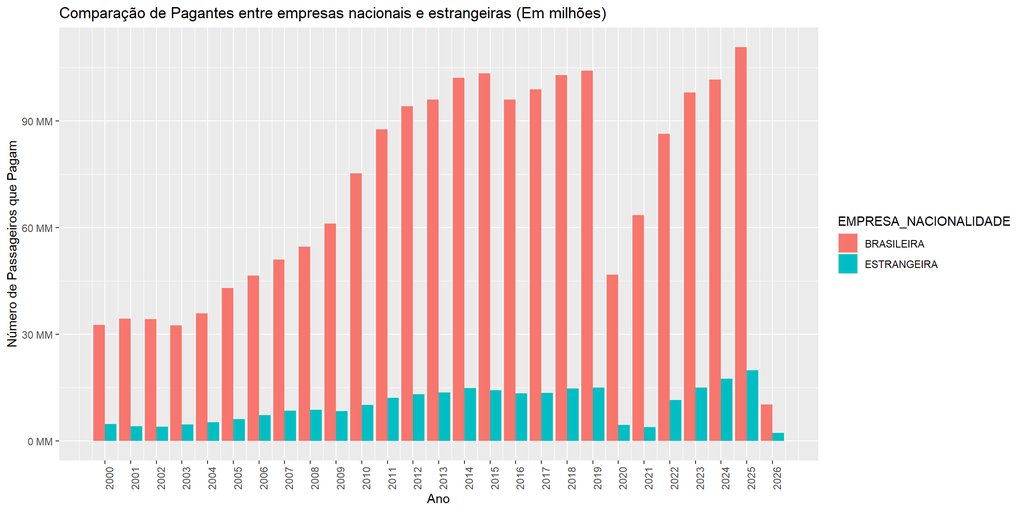

```r
ggplot(questao_2_lista3,
       mapping = aes(x = ANO, y = passageiro_pagantes, fill = EMPRESA_NACIONALIDADE)) +
        geom_col (position = "dodge")+
        labs(
          title = "Comparação de Pagantes entre empresas nacionais e estrangeiras (Em milhões)",
          x = "Ano",
          y = "Número de Passageiros que Pagam"
            ) +
        scale_x_continuous(breaks = seq(min(questao_2_lista3$ANO), max(questao_2_lista3$ANO), by = 1))+
        scale_y_continuous(labels = scales::label_number(scale = 1e-6, suffix = " MM")) +
        theme(
          axis.text.x = element_text(angle = 90, hjust = 1),
          strip.text = element_text(size = 10)
              )
```

## Questão 3

*3-) Faça uma visualização de dados comparar o número de passageiros pagantes entre empresas nacionais eestrangeiras de acordo com o grupo de voo.*

```r
questao_3_lista3 <- dados %>%
                    filter(!is.na(GRUPO_DE_VOO), GRUPO_DE_VOO!="NÃO IDENTIFICADO") %>%
                    group_by(GRUPO_DE_VOO, EMPRESA_NACIONALIDADE) %>%
                    summarise(passageiro_pagantes = sum(PASSAGEIROS_PAGOS, na.rm=TRUE))%>%
                    group_by(EMPRESA_NACIONALIDADE) %>%
                    mutate(percentual = passageiro_pagantes / sum(passageiro_pagantes))
```

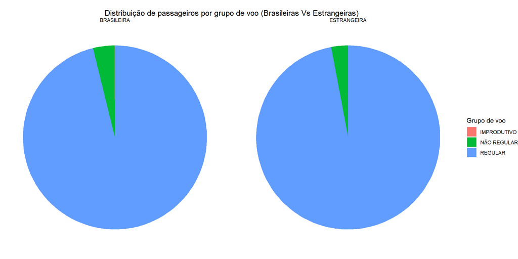

```r
ggplot(questao_3_lista3,
       aes(x = "", y = percentual, fill = GRUPO_DE_VOO)) +
      geom_col(width = 1) +
      coord_polar(theta = "y") +
      facet_wrap(~EMPRESA_NACIONALIDADE) +

      labs(
        title = "Distribuição de passageiros por grupo de voo (Brasileiras Vs Estrangeiras)",
        fill = "Grupo de voo"
      ) +

      theme_void() +  # remove tudo

      theme(
        plot.title = element_text(hjust = 0.5)
      )
```

## Questão 4

*4-) Faça uma visualização para enfatizar a distribuição da variável número de passageiros pagantes de acordo com a região de origem e natureza do voo. Enfatize a comparação entre DOMÉSTICA e INTERNACIONAL para cada região de origem. Para criar o gráfico use o log10 da variávelPASSAGEIROS_PAGOS.*

```r
questao_4_lista3 <- dados %>%
                    filter(!is.na(AEROPORTO_DE_ORIGEM_REGIAO)) %>%
                    group_by(AEROPORTO_DE_ORIGEM_REGIAO,NATUREZA) %>%
                    summarise(passageiro_pagantes = sum(PASSAGEIROS_PAGOS, na.rm=TRUE))
```

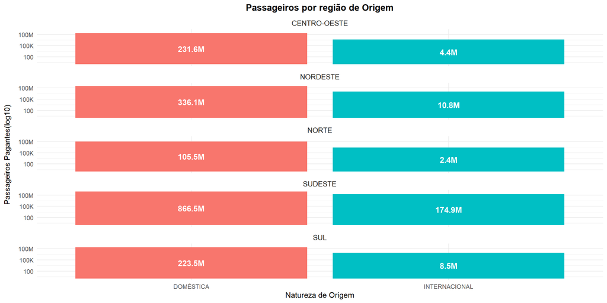

```r
ggplot(questao_4_lista3, aes(x = NATUREZA, y = passageiro_pagantes, fill = NATUREZA)) +
        geom_col (position = "dodge") +
        scale_y_log10(labels = scales::label_number(scale_cut = scales::cut_short_scale()))+
        facet_wrap(~AEROPORTO_DE_ORIGEM_REGIAO,ncol = 1, labeller = label_wrap_gen(width = 45))+
        labs(
          title = "Passageiros por região de Origem",
          x = "Natureza de Origem",
          y = "Passageiros Pagantes(log10)"
        ) +
        theme_minimal() +
        theme(
          plot.title = element_text(hjust = 0.5, face = "bold"),
          axis.text.x = element_text(angle = 0, hjust = 0.5),
          strip.text = element_text(size = 10),
          legend.position = "none"
             )+
        facet_wrap(~AEROPORTO_DE_ORIGEM_REGIAO,ncol = 1, labeller = label_wrap_gen(width = 45))+
        labs(
          title = "Passageiros por região de Origem",
          x = "Natureza de Origem",
          y = "Passageiros Pagantes(log10)"
        ) +
        theme_minimal() +
        theme(
          plot.title = element_text(hjust = 0.5, face = "bold"),
          axis.text.x = element_text(angle = 0, hjust = 0.5),
          strip.text = element_text(size = 10),
          axis.title.y = element_text(margin = margin(r = 10)),
          legend.position = "none"
             )+
        geom_text(
          aes(label = scales::label_number(scale_cut =  scales::cut_short_scale())(passageiro_pagantes)),
          position = position_stack(vjust = 0.5),
          color = "white",
          fontface = "bold",
          size = 4
        )
```

## Questão 5

*5-) Crie uma variável que indique a eficiencia no uso do combustível como sendo a razão entre o DISTANCIA_VOADA_KM e COMBUSTIVEL_LITROS. Compare as empresas de acordo com a região de origem e destino. Use a escala y em log10 para facilitar a comparação das regiões.*

```r
questao_5_lista3 <- dados %>%
                    filter(!is.na(AEROPORTO_DE_DESTINO_REGIAO),!is.na(AEROPORTO_DE_ORIGEM_REGIAO),!is.na(DISTANCIA_VOADA_KM), !is.na(COMBUSTIVEL_LITROS), COMBUSTIVEL_LITROS>0, DISTANCIA_VOADA_KM>0) %>%
                    group_by(AEROPORTO_DE_ORIGEM_REGIAO,AEROPORTO_DE_DESTINO_REGIAO ) %>%
                    summarise(consumo_KM_L = sum(DISTANCIA_VOADA_KM) / sum(COMBUSTIVEL_LITROS), .groups = "drop") %>%
                    arrange(desc(consumo_KM_L)) #%>%
                    #slice_head(n = 50)# somentes as cinco principais empresas
```

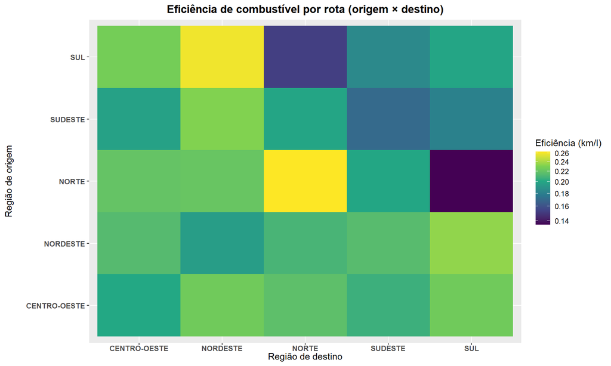

```r
ggplot(questao_5_lista3,
       aes(x = AEROPORTO_DE_DESTINO_REGIAO,
           y = AEROPORTO_DE_ORIGEM_REGIAO,
           fill = consumo_KM_L)) +
        geom_tile()+
        scale_fill_viridis_c(trans = "log10") +
        labs(
          title = "Eficiência de combustível por rota (origem × destino)",
          x = "Região de destino",
          y = "Região de origem",
          fill = "Eficiência (km/l)"
        ) +
        theme(
          plot.title = element_text(hjust = 0.5, face = "bold"),
          axis.text.x = element_text(angle = 0, hjust = 0.5, margin = margin(r = 15), face = "bold"),
          axis.text.y = element_text(face = "bold"),
          strip.text = element_text(size = 10),
          axis.title.y = element_text(margin = margin(r = 15)),
          axis.title.x = element_text(margin = margin(r = 25)),
          legend.position = "right"

             )
```

## Questão 6

*6-) Faça uma visualização para mostrar a relação entre o consumo de combustível e a distância voada. Considere empresas nacionais e internacionais e os diferentes anos para enriquecer a visualização. Considere transformar as variáveis e use alguma forma estatística para enfatizar a forma do relacionamento.*

Importante

```r
questao_6_lista3 <- dados %>%
                    filter(!is.na(DISTANCIA_VOADA_KM),!is.na(COMBUSTIVEL_LITROS), COMBUSTIVEL_LITROS>50, DISTANCIA_VOADA_KM>100,DISTANCIA_VOADA_KM<20000, ANO>2020) %>%
                    group_by(EMPRESA_NACIONALIDADE,ANO, DISTANCIA_VOADA_KM) %>%
                    mutate(consumo_KM_L = DISTANCIA_VOADA_KM / COMBUSTIVEL_LITROS)
```

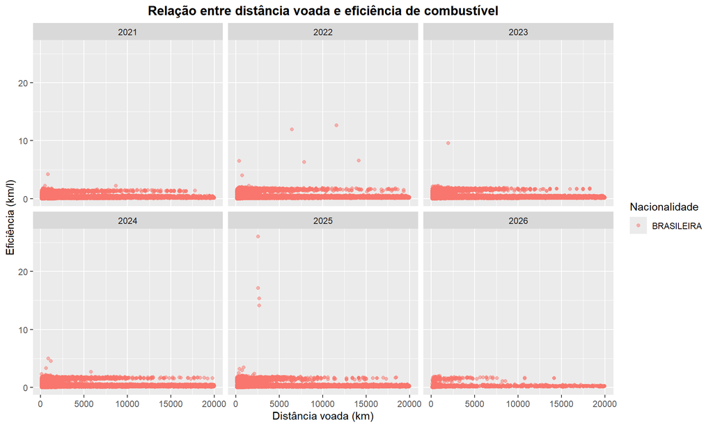

```r
ggplot(questao_6_lista3,
       aes(x = DISTANCIA_VOADA_KM,
           y = consumo_KM_L,
           color = EMPRESA_NACIONALIDADE)) +
           geom_point(alpha = 0.5) +
                     facet_wrap(~ANO) +
                      labs(
              title = "Relação entre distância voada e eficiência de combustível",
              x = "Distância voada (km)",
              y = "Eficiência (km/l)",
              color = "Nacionalidade"
            ) +
            theme(plot.title = element_text(hjust = 0.5, face = "bold"))
```

Percebemos que existem algumas discrepâncias nesta análise, uma vez que não aparem empresas estrangeiras e também há eficiências muito elevadas, que distoam.

## Questão 7

*7-) Baseado na visualização em 6 você diria que tem alguma incosistencia com esses dados? Justique.*

Resposta: Conforme relatado na questão 6.

## Questão 8

*8-) Considerando apenas as empresas nacionais. Faça uma visualização para investigar se a região do aeroporto de origem influencia na relação entre combustível e distancia voada.*

```r
questao_8_lista3 <- dados %>%
                    filter(EMPRESA_NACIONALIDADE == "BRASILEIRA", !is.na(AEROPORTO_DE_ORIGEM_REGIAO), COMBUSTIVEL_LITROS>0, DISTANCIA_VOADA_KM>0,DISTANCIA_VOADA_KM<20000 ) %>%
                    group_by(AEROPORTO_DE_ORIGEM_REGIAO,  DISTANCIA_VOADA_KM) %>%
                    mutate(consumo_KM_L = DISTANCIA_VOADA_KM / COMBUSTIVEL_LITROS)
```

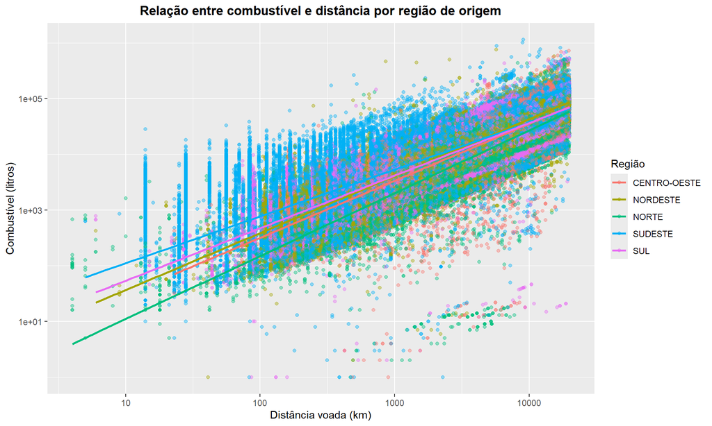

```r
ggplot(questao_8_lista3,
       aes(x = DISTANCIA_VOADA_KM,
           y = COMBUSTIVEL_LITROS,
            color = AEROPORTO_DE_ORIGEM_REGIAO)) +
            scale_x_log10() +
            scale_y_log10() +
            geom_point(alpha = 0.4) +
            geom_smooth(method = "lm", se = FALSE) +
            labs(
              title = "Relação entre combustível e distância por região de origem",
              x = "Distância voada (km)",
              y = "Combustível (litros)",
              color = "Região"
            ) +
            theme(plot.title = element_text(hjust = 0.5, face = "bold"))
```

## Questão 9

*9-) O indicador RTK (Revenue tonne kilometer) refere-se ao volume de toneladas quilômetros transportada.Faça uma visualização da relação deste indicador com o consumo de combustível. Filtre apenas observações com ambas variáveis maiores que zero. Considere também que é de interesse comparar essarelação entre os diferentes anos. Considere incluir alguma camada estatística para enfatizar o formato do relacionamento entre as variáveis.*

```r
questao_9_lista3 <- dados %>%
                    filter(!is.na(RTK), COMBUSTIVEL_LITROS>0, RPK>0, DISTANCIA_VOADA_KM>0, ANO>2020)
```

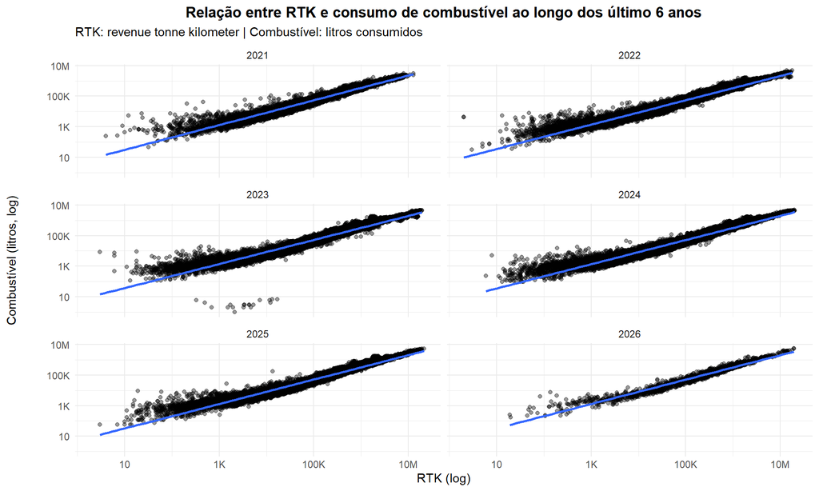

```r
ggplot(questao_9_lista3,
       aes(x = RTK,
           y = COMBUSTIVEL_LITROS),
           color = ANO
           ) +
          geom_point(alpha = 0.4) +
          geom_smooth(method = "lm", se = FALSE) +

          facet_wrap(~ANO,ncol = 2) +

          scale_x_log10(labels = scales::label_number(scale_cut = scales::cut_short_scale())) +
          scale_y_log10(labels = scales::label_number(scale_cut = scales::cut_short_scale())) +

          labs(
            title = "Relação entre RTK e consumo de combustível ao longo dos último 6 anos",
            x = "RTK (log)",
            y = "Combustível (litros, log)",
            subtitle = "RTK: revenue tonne kilometer | Combustível: litros consumidos"
          ) +

          theme_minimal()+
          theme(plot.title = element_text(hjust = 0.5, face = "bold"),
                axis.text.x = element_text(angle = 0, hjust = 0.5, margin = margin(r = 15)),
                axis.title.y = element_text(margin = margin(r = 25)),
                legend.position = "right"
               )
```

## Questão 10

*10-)O indicador ATK (Available tonne kilometer) refere-se ao volume de tonelada quilômetro oferecida pela companhia. Crie uma visualização para explorar a relação entre estes indicadores. Considere aspectos como GRUPO_DE_VOO e NATUREZA além do anos.*

```r
questao_10_lista3 <- dados %>%
                     filter(!is.na(ATK), !is.na(GRUPO_DE_VOO) ) %>%
                     group_by(GRUPO_DE_VOO,  NATUREZA)
```

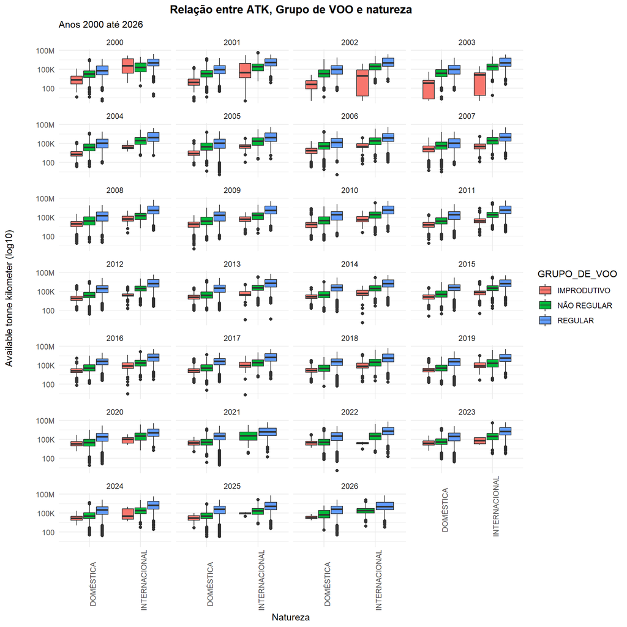

[figure not shown]

```r
ggplot(questao_10_lista3,
       aes(x = NATUREZA,
           y = ATK,
           fill = GRUPO_DE_VOO)) +

          geom_boxplot() +

          facet_wrap(~ANO, ncol= 4) +

          scale_y_log10(labels = scales::label_number(scale_cut = scales::cut_short_scale())) +

          theme_minimal()+

          labs(
            title = "Relação entre ATK, Grupo de VOO e natureza",
            x = "Natureza",
            y = "Available tonne kilometer (log10)",
            subtitle = "Anos 2000 até 2026"
              ) +


          theme(plot.title = element_text(hjust = 0.5, face = "bold"),
          axis.text.x = element_text(angle = 90, hjust = 0.25, margin = margin(r = 15)),
          axis.title.y = element_text(margin = margin(r = 25)),
          legend.position = "right"
                )
```

Gustavo Finger

https://www.youtube.com/@prof.gustavofinger